# R Notebook

```r
rm(list=ls())
setwd("/home/tauro/Projects/quizziz")
library(jsonlite)
library(lubridate)
library(dplyr)
library(ggplot2)
#library(reshape2)
#library(purrr)
options(scipen=999)
```

```r
data <- stream_in(file("data_role_assignment.json"), verbose = FALSE)
```

Some data preprocessing

```r
params <- lapply(data$params, "[[", 2)
params <- setNames(do.call(rbind.data.frame, params),
                       c("sessionId", "page", "userId"))
data$params <- NULL
data <- cbind(data, params)
rm(params)
data$serverTime <- ymd_hms(data$serverTime, tz="UTC")
data$day <- day(data$serverTime)
data$month <- month(data$serverTime)
data$hour <- hour(data$serverTime)
data$wday <- wday(data$serverTime, label=TRUE)
categorical_cols <- c("version", "eventId", "sessionId", "page", "userId", "day",
                      "month", "hour", "wday")
data$wday <- as.factor(as.character(data$wday))
data[categorical_cols] <- lapply(data[categorical_cols], factor)
#Filling in missing userIds for the same session
data <- data %>% group_by(sessionId) %>% mutate("userId" = first(userId))
data$is_reg <- as.factor(as.integer(is.na(data$userId)))
```

### Metric 1) Number of events (n_events)

The first metric we look at is the number of events. Here, *n_events* is the number of events for a particular session.

```r
#Number of events per session across both versions
eventsPerSessionAB <- data %>% select(everything()) %>%
  group_by(sessionId, version, is_reg) %>% summarise("n_events" = length(eventId)) %>%
  arrange(desc(n_events))
eventsPerSessionAB
```

| sessionId | version | is_reg | n_events |
| --- | --- | --- | --- |
| 3149655934875133.5-0531211005509 | A | 0 | 97 |
| 6806286385066675-0531081108826 | B | 1 | 69 |
| 5971421104474900-0529655653827 | B | 1 | 62 |
| 5112061776162483-0529586357871 | B | 1 | 61 |
| 2139220364593765.8-0529763310479 | B | 0 | 52 |
| 7593663885154540-0531052882995 | B | 1 | 47 |
| NaN-0531054367270 | B | 1 | 45 |
| 6491586572480890-0531073400997 | B | 0 | 42 |
| 8454131905272713-0529767624171 | B | 1 | 42 |
| 8054399907552187-0529995340346 | B | 1 | 38 |

[output cut: 990 more lines]

We can try to perform a statistical test here. But before that, we need to see if the variable of interest is normally distributed.

Testing for normality of *n_events* through a random sample (Shapiro’s test)

```r
shapiro.test(sample(eventsPerSessionAB$n_events, 3000))
```

```
    Shapiro-Wilk normality test

data:  sample(eventsPerSessionAB$n_events, 3000)
W = 0.63952, p-value < 0.00000000000000022
```

```r
#Cannot assume normality, hence not ideal to perform t-test directly
```

The results clearly show conclusive evidence against the null hypothesis (that *n_events* is normally distributed)

Usually, one performs a two-sample Student’s t-test of the means of two populations. But since the t-test assumes the data to be normally distributed and our data indicates otherwise, we need an alternative.

We perform the Mann-Whitney-Wilcox test which does not assume normality.

1. n_events grouped by version

```r
wilcox.test(n_events ~ version, data=eventsPerSessionAB)
```

```
    Wilcoxon rank sum test with continuity correction

data:  n_events by version
W = 208380000, p-value < 0.00000000000000022
alternative hypothesis: true location shift is not equal to 0
```

The number of events for both versions are not identically distributed

2) n_events grouped by registration status

```r
wilcox.test(n_events ~ is_reg, data=eventsPerSessionAB)
```

```
    Wilcoxon rank sum test with continuity correction

data:  n_events by is_reg
W = 210540000, p-value = 0.00000000285
alternative hypothesis: true location shift is not equal to 0
```

The number of events for registered and non_registered sessions are not identically distributed

Based on the results of the Mann-Whitney-Wilcox test, we can conclude that the differences in *n_events* by version and registered status are statistically significant

Plotting n_events by version

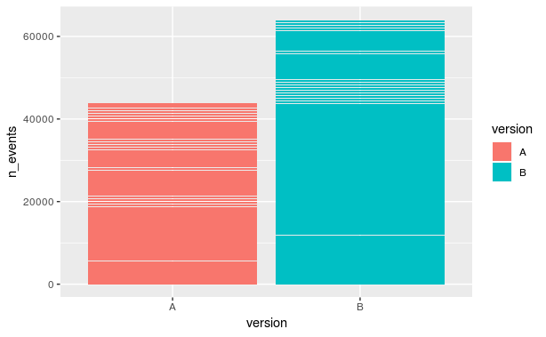

```r
ggplot(eventsPerSessionAB, aes(x=version, y=n_events, fill=version)) +
  geom_bar(stat="identity")
```

Now we look at the mean number of events per session across both versions (including bounces)

```r
mean_eventsPerSessionAB_inc_bounce <- eventsPerSessionAB  %>% group_by(version) %>%
  summarise("mean_n_events" = mean(n_events))
mean_eventsPerSessionAB_inc_bounce
```

| version | mean_n_events |
| --- | --- |
| A | 1.748253 |
| B | 2.545487 |

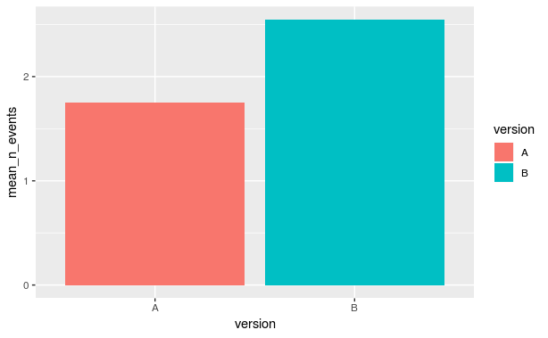

```r
ggplot(mean_eventsPerSessionAB_inc_bounce, aes(x=version, y=mean_n_events, fill=version)) + geom_bar(stat="identity")
```

Similarly we look at the mean number of events per session across both versions (excluding bounces)

```r
mean_eventsPerSessionAB_exc_bounce <- eventsPerSessionAB %>% filter(n_events > 1) %>%
  group_by(version) %>% summarise("mean_n_events" = mean(n_events))
mean_eventsPerSessionAB_exc_bounce
```

| version | mean_n_events |
| --- | --- |
| A | 3.251682 |
| B | 3.304356 |

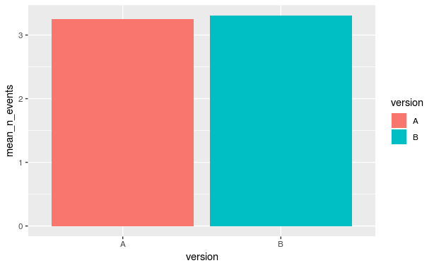

```r
ggplot(mean_eventsPerSessionAB_exc_bounce, aes(x=version, y=mean_n_events, fill=version)) + geom_bar(stat="identity")
```

Here, we can see that version B generates more number of events and consequently has a higher number of mean events.

We now check which pages drove how many events

```r
eventsPerPage <- data %>% group_by(page, version) %>%
  summarise("n_events" = length(eventId)) %>% group_by(version) %>% arrange(desc(n_events))
eventsPerPage
```

| page | version | n_events |
| --- | --- | --- |
| signup_type_select | B | 51359 |
| signup_type | A | 28118 |
| select_occupation | A | 10051 |
| signup_role_picker | B | 8007 |
| signup_dob_check | B | 1967 |
| signup_account_info | B | 1813 |
| signup_main | A | 1801 |
| signup_main_student | A | 1648 |
| select_grade_student | A | 1103 |
| select_org | A | 1071 |

[output cut: 5 more lines]

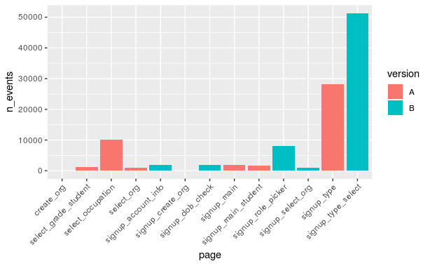

```r
ggplot(eventsPerPage, aes(x=page, y=n_events, fill=version)) +
  geom_bar(stat="identity") + theme(axis.text.x = element_text(angle=45, hjust=1))
```

### Time spent in a session (session_duration)

Now we look at a second metric, the duration of time spent by users on both versions.

```r
timePerSessionAB <- data %>% select(sessionId, version, serverTime) %>%
  arrange(serverTime) %>%
  group_by(sessionId, version) %>%
  summarise("session_duration" = as.numeric(last(serverTime) - first(serverTime),
                                            units = "mins"))
timePerSessionAB
```

| sessionId | version | session_duration |
| --- | --- | --- |
| 0000380802421095.9-0529718317435 | B | 2.71666667 |
| 000042594089485.98-0529968044866 | B | 0.05000000 |
| 0000591060603443.9-0531182978688 | B | 0.00000000 |
| 0000617186038898.9-0529876143371 | A | 0.00000000 |
| 0000792954124260.9-0531088856248 | B | 25.61666667 |
| 0002014200214197.9-0531020121739 | A | 0.00000000 |
| 0002117489093016.9-0531279760481 | B | 0.08333333 |
| 0002414611200740.9-0529807959526 | B | 0.20000000 |
| 0002417965433855.9-0531186345034 | A | 0.00000000 |
| 0002657341410519.9-0531066556626 | B | 1.90000000 |

[output cut: 990 more lines]

We could perform a statistical test, so we test for normality again.

```r
session_duration_A <- c(timePerSessionAB[timePerSessionAB$version=="A",]$sessionId)
session_duration_B <- c(timePerSessionAB[timePerSessionAB$version=="B",]$sessionId)
shapiro.test(sample(session_duration_A, 3000))
```

```
    Shapiro-Wilk normality test

data:  sample(session_duration_A, 3000)
W = 0.95396, p-value < 0.00000000000000022
```

```r
shapiro.test(sample(session_duration_B, 3000))
```

```
    Shapiro-Wilk normality test

data:  sample(session_duration_B, 3000)
W = 0.95877, p-value < 0.00000000000000022
```

Since the p-value is close to zero, the null hypothesis is rejected and session duration variables (for both versions) are not normally distributed.

Hence we perform the Mann-Whitney-Wilcox test again, just to be more confident of the results.

```r
wilcox.test(session_duration_A, session_duration_B, alternative="greater")
```

```
    Wilcoxon rank sum test with continuity correction

data:  session_duration_A and session_duration_B
W = 318010000, p-value = 0.03823
alternative hypothesis: true location shift is greater than 0
```

The null hypothesis is that there is no difference between the means of the two populations. Because the p-value is lower than the threshold (0.05 by default), it is rejected.

Now we perform a Student’s t-test anyway, just to compare it with the one above.

```r
t.test(session_duration_A, session_duration_B, alternative="greater")
```

```
    Welch Two Sample t-test

data:  session_duration_A and session_duration_B
t = 1.7718, df = 50200, p-value = 0.03822
alternative hypothesis: true difference in means is greater than 0
95 percent confidence interval:
 16.33804      Inf
sample estimates:
mean of x mean of y
 25091.28  24863.15
```

The p-value is almost identical to the one obtained in the Wilcox test and the null hypothesis is again rejected.

```r
mean_timePerSessionAB <- timePerSessionAB %>% filter(session_duration > 0) %>%
  group_by(version) %>% summarise("mean_session_duration" = mean(session_duration))
mean_timePerSessionAB
```

| version | mean_session_duration |
| --- | --- |
| A | 3.988012 |
| B | 2.659263 |

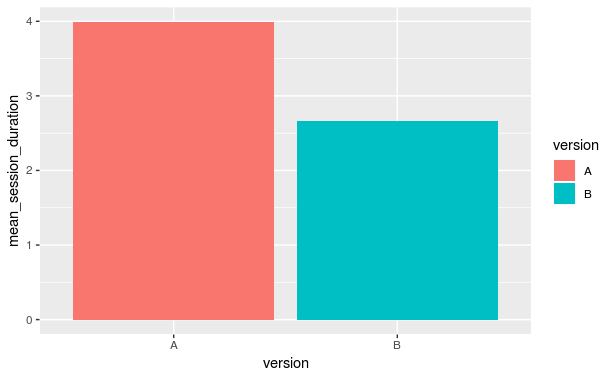

```r
ggplot(mean_timePerSessionAB, aes(x=version, y=mean_session_duration, fill=version)) +
  geom_bar(stat="identity")
```

We see that, on average, people spend more time on version A.

Since all the pages contained in the data are registration-related, it is my assumption that something is causing users on version A to spend more time on this task.

This can potentially have undesirable effects, because people usually want to be done with it as quickly as possible.

Looking at the mean time spent per page -

```r
mean_timeSpentPerPage <- timeSpentPerPage %>% group_by(page, version) %>%
  summarise("mean_time_spent_mins" = mean(time_spent_mins)) %>% arrange(desc(mean_time_spent_mins))
mean_timeSpentPerPage
```

| page | version | mean_time_spent_mins |
| --- | --- | --- |
| signup_type_select | B | 1.73261205 |
| signup_type | A | 1.20813187 |
| signup_main | A | 0.88550136 |
| signup_dob_check | B | 0.65064565 |
| signup_main_student | A | 0.57275261 |
| select_occupation | A | 0.43992594 |
| signup_role_picker | B | 0.15566358 |
| signup_account_info | B | 0.12504885 |
| select_org | A | 0.09608031 |
| select_grade_student | A | 0.01765873 |

[output cut: 5 more lines]

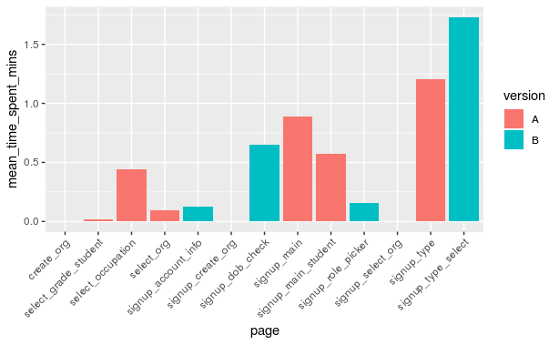

```r
ggplot(mean_timeSpentPerPage, aes(x=page, y=mean_time_spent_mins, fill=version)) +
  geom_bar(stat="identity") +theme(axis.text.x = element_text(angle=45, hjust=1))
```

While version A overall sees more time spent on average, the ‘signup_type_select’ page of version B sees an inordinately higher number for that metric.

### Metric 3 - Number of registered users (n_users)

The number of registered users can be seen here -

```r
users_total <- length(data$userId[!(is.na(data$userId))])
users_total
```

```
[1] 24282
```

Of these, the number of unique users are -

```r
users_unique_total <- length(unique(data$userId[!(is.na(data$userId))]))
users_unique_total
```

```
[1] 9805
```

Now we look at the number of registered users per version.

```r
numUsersAB <- data %>% filter(!(is.na(userId))) %>% group_by(version) %>%
  summarise("n_users" = length(userId), "percentage" = 100 * n_users/users_total)
numUsersAB
```

| version | n_users | percentage |
| --- | --- | --- |
| A | 7514 | 30.94473 |
| B | 16768 | 69.05527 |

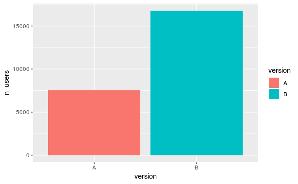

```r
ggplot(numUsersAB, aes(x=version, y=n_users, fill=version)) +
  geom_bar(stat="identity")
```

More than twice as many registered users end up on version B. This means the bulk of users on version A are unregistered.

Just to be sure, we look at the number of unique registered users per version.

```r
numUniqueUsersAB <- data %>% filter(!(is.na(userId))) %>% group_by(version) %>%
  summarise("n_users" = length(unique(userId)), "percentage" = 100 * n_users/users_unique_total)
numUniqueUsersAB
```

| version | n_users | percentage |
| --- | --- | --- |
| A | 3870 | 39.46966 |
| B | 6074 | 61.94799 |

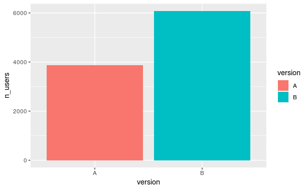

```r
ggplot(numUniqueUsersAB, aes(x=version, y=n_users, fill=version)) +
  geom_bar(stat="identity")
```

Again, we see a similar pattern. More registered users going to B than A.

```r
bounced_yesno <- data %>% select(everything()) %>%
  group_by(sessionId, version, is_reg) %>% summarise("n_events" = length(eventId)) %>%
  mutate("bounced" = as.integer(!n_events == 1)) %>% ungroup() %>%
  select(sessionId, bounced)

bounced_yesno$bounced <- as.factor(bounced_yesno$bounced)

bounced_yesno
```

[output not shown]

We now look at the bounce rate itself for each version

```r
bounce_rate <- eventsPerSessionAB %>% filter(n_events == 1) %>% group_by(version) %>%
  summarise("bounce_rate" = 100 * (length(n_events)/length(eventsPerSessionAB$n_events)))
bounce_rate
```

| version | bounce_rate |
| --- | --- |
| A | 33.31010 |
| B | 16.50269 |

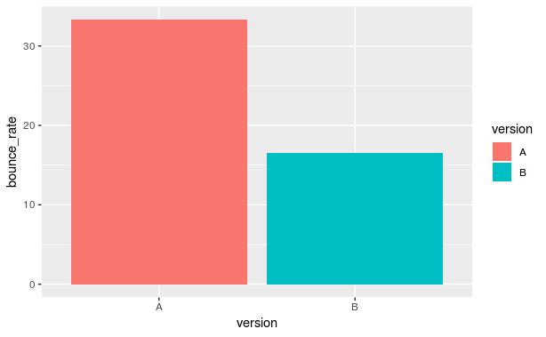

```r
ggplot(bounce_rate, aes(x=version, y=bounce_rate, fill=version)) +
  geom_bar(stat="identity")
```

```r
ggplot(bounce_rate, aes(x=version, y=bounce_rate, fill=version)) +
  geom_bar(stat="identity")
```

[output not shown]

We see that version A has a much higher bounce rate, about twice as much as B.

We now investigate the bounce rate across pages.

```r
bouncesPerPage <- data %>% group_by(sessionId, version, page) %>%
  summarise("n_events" = n()) %>% filter(n_events == 1) %>%
  group_by(page, version) %>% summarise("n_bounces" = n()) %>%
  group_by(version) %>% mutate("prop_bounce_for_version" = n_bounces/sum(n_bounces)) %>%
  arrange(desc(prop_bounce_for_version))
bouncesPerPage
```

| page | version | n_bounces | prop_bounce_for_version |
| --- | --- | --- | --- |
| signup_type | A | 17572 | 0.58932823557 |
| signup_role_picker | B | 7369 | 0.45459592844 |
| signup_type_select | B | 5658 | 0.34904380012 |
| select_occupation | A | 7563 | 0.25364724821 |
| signup_account_info | B | 1653 | 0.10197409007 |
| signup_select_org | B | 893 | 0.05508945096 |
| signup_main | A | 1286 | 0.04312975819 |
| signup_main_student | A | 1279 | 0.04289499279 |
| signup_dob_check | B | 629 | 0.03880320790 |
| select_grade_student | A | 1085 | 0.03638863735 |

[output cut: 5 more lines]

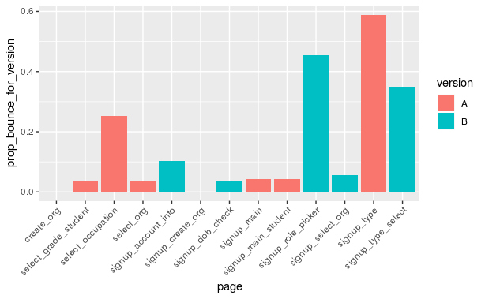

```r
ggplot(bouncesPerPage, aes(x=page, y=prop_bounce_for_version, fill=version)) +
  geom_bar(stat="identity") + theme(axis.text.x = element_text(angle=45, hjust=1))
```

We can investigate the number of bounces per day of the week.

```r
bouncesPerWDay <- data %>% select(everything()) %>%
  group_by(sessionId, wday, version) %>% summarise("n_events" = length(eventId)) %>%
  filter(n_events == 1) %>% group_by(wday, version) %>%
  summarise("n_bounces" = length(n_events))
bouncesPerWDay
```

| wday | version | n_bounces |
| --- | --- | --- |
| Fri | A | 3718 |
| Fri | B | 1857 |
| Mon | A | 2558 |
| Mon | B | 1226 |
| Sat | A | 541 |
| Sat | B | 372 |
| Sun | A | 730 |
| Sun | B | 426 |
| Thu | A | 4044 |
| Thu | B | 1921 |

[output cut: 4 more lines]

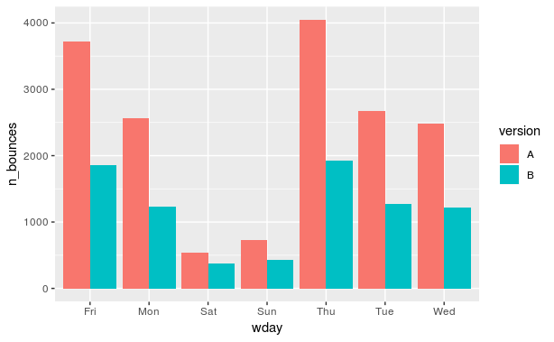

```r
ggplot(bouncesPerWDay, aes(x=wday, y=n_bounces, fill=version)) +
  geom_bar(stat="identity", position="dodge")
```

#### So far, most of what we have seen are charts and tables constructed from the population. They give us a hint but aren’t statistically robust to be counted as definitive evidence.

#### It is better we perform a formal statistical experiment (an A-B test) using the metric we have derived above.

We derive the proportion of non-bounces (a user not bouncing is assumed to be a success here).

```r
nonBouncePerVersion <- data %>% select(everything()) %>% group_by(sessionId, version) %>%
  summarise("n_events" = length(eventId)) %>%
  group_by(version) %>%
  summarise("sessions_not_bounced" = length(sessionId[n_events > 1]),
            "sessions_bounced" = length(sessionId[n_events == 1]),
            "total_session" = length(sessionId))
nonBouncePerVersion
```

| version | sessions_not_bounced | sessions_bounced | total_session |
| --- | --- | --- | --- |
| A | 8324 | 16725 | 25049 |
| B | 16875 | 8286 | 25161 |

Now, we find the ratio of non-bounces (successes) to the total number of visitors (trials) for each version.

```r
vec_A <- c()
vec_B <- c()
vec_labs <- c("num_trials", "num_successes", "proportion_successful")
n_trials_A <- subset(nonBouncePerVersion, version=="A")$total_session
vec_A <- c(vec_A, n_trials_A)
n_trials_B <- subset(nonBouncePerVersion, version=="B")$total_session
vec_B <- c(vec_B, n_trials_B)
n_success_A <- subset(nonBouncePerVersion, version=="A")$sessions_not_bounced
vec_A <- c(vec_A, n_success_A)
n_success_B <- subset(nonBouncePerVersion, version=="B")$sessions_not_bounced
vec_B <- c(vec_B, n_success_B)
pA <- n_success_A/n_trials_A
vec_A <- c(vec_A, pA)
pB <- n_success_B/n_trials_B
vec_B <- c(vec_B, pB)
prop_success <- data.frame("Metric" = vec_labs, "Version A" = vec_A, "Version B" = vec_B)
prop_success
```

| Metric | Version.A | Version.B |
| --- | --- | --- |
| num_trials | 25049.0000000 | 25161.0000000 |
| num_successes | 8324.0000000 | 16875.0000000 |
| proportion_successful | 0.3323087 | 0.6706808 |

Now that we have obtained the values for pA and pB, we may use this information in the test.

Since this is a yes-no evaluation, we can perform a Binomial test and use the binomial distribution to approximate the pattern of successes.

Here, we perform a Binomial test with the null hypothesis being that pA is greater than n_success_B/25,000 trials (~pB).

```r
binom.test(n_success_B, 25000, p=pA, alternative="greater")
```

[output not shown]

Similary, another Binomial test with the null hypothesis being that pB is lesser than ~pA

```r
binom.test(n_success_A, 25000, p=pB, alternative="less")
```

[output not shown]

As the actual number of trials are ~25,000 for A and B, we give each version that many trials in the A-B test also.

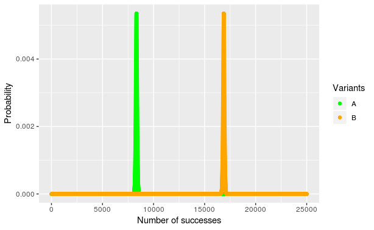

```r
x_A <- 1:25000
y_A <- dbinom(x_A, n_trials_A, pA)
x_B <- 1:25000
y_B <- dbinom(x_B, n_trials_B, pB)
df <- data.frame(x_A=x_A, y_A=y_A, x_B=x_B, y_B=y_B)
options(repr.plot.width=5, repr.plot.height=3)
cols = c("A"="green","B"="orange")
ggplot(data = df)+
  labs(x="Number of successes", y="Probability") + xlim(0, 25000) +
  geom_point(aes(x=x_A, y=y_A, colour="A")) +
  geom_point(aes(x=x_B, y=y_B, colour="B")) +
  scale_colour_manual(name="Variants", values=cols)
```

From the binomial distribution using our values of pA and pB, it is clear that version B has a higher number of successes.

It would appear that version B is likely the better one.

However, this experiment is only a single trial. Ideally, we would like to repeat this experiment several times just to be certain that our observations are correct.

To achieve this, we employ the Central Limit Theorem to (safely) assume that the means of a large number of independent, identically distributed variables are normally distributed.

Because of this, we can instead model the data under a normal distribution this time around.

```r
x_A_clt = seq(from=0.005, to=0.95, by=0.00001)
y_A_clt = dnorm(x_A_clt, mean = pA, sd = sqrt((pA * (1-pA))/25000))

x_B_clt = seq(from=0.005, to=0.95, by=0.00001)
y_B_clt = dnorm(x_B_clt, mean = pB, sd = sqrt((pB * (1-pB))/25000))

df = data.frame(x_A_clt=x_A_clt, y_A_clt=y_A_clt, x_B_clt=x_B_clt, y_B_clt=y_B_clt)
options(repr.plot.width=7, repr.plot.height=3)
cols = c("A"="green","B"="orange")
ggplot(data = df)+
  labs(x="Proportions value", y="Probability Density Function") +
  geom_point(aes(x=x_A_clt, y=y_A_clt, colour="A")) +
  geom_point(aes(x=x_B_clt, y=y_B_clt, colour="B")) +
  scale_colour_manual(name="Variants", values=cols)
```

[output not shown]

We can state with reasonable confidence that version B is the better one.

NB- Along with a few more data projections, I did a some ANOVA and correlation tests, but for the sake of avoiding needless redundancy and having generated a conclusion even without them, I chose not to include them in the document. They are still accessible in my code (insights.R)